# gtfs2gps: Converting GTFS data to GPS-like format

Rafael H. M. Pereira, Pedro R. Andrade, Joao Bazzo

18 August 2020

# Introduction

```r
install.packages("gtfs2gps")
```

# Loading data

After loading the package, GTFS data can be read into R by using `read_gtfs()`. This function gets a zipped GTFS file and returns a list of `data.table` objects. The returning list contains the data of each GTFS file indexed according to their file names without extension.

```r
library("gtfs2gps")
poa <- read_gtfs(system.file("extdata/poa.zip", package ="gtfs2gps"))
```

[output not shown]

```r
names(poa)
```

```
## [1] "agency"     "calendar"   "routes"     "shapes"     "stop_times"
## [6] "stops"      "trips"
```

```r
head(poa$trips)
```

```
##    route_id service_id    trip_id shape_id
## 1:       T2       T2@1 T2-1@1#520     T2-1
## 2:       T2       T2@1 T2-1@1#540     T2-1
## 3:       T2       T2@1 T2-1@1#555     T2-1
## 4:       T2       T2@1 T2-1@1#610     T2-1
## 5:       T2       T2@1 T2-1@1#620     T2-1
## 6:       T2       T2@1 T2-1@1#628     T2-1
```

Note that not all GTFS files are loaded into R. This function only loads the necessary data to spatially and temporally handle trips and stops, which are: “shapes.txt”, “stop_times.txt”, “stops.txt”, “trips.txt”, “agency.txt”, “calendar.txt”, “routes.txt”, and “frequencies.txt”, with this last four being optional. If a given GTFS zipped file does not contain all of these required files then `read_gtfs()` will stop with an error.

# Subsetting GTFS Data

GTFS data sets can be fairly large for complex public transport networks and, in some cases, users might want to focus on specific transport services at week days/weekends, or on specific trips or routes. The package brings some functions to filter GTFS.zip and speed up the data processing.

- **filter_by_shape_id():** Filter shapes using given shape ids.
- **filter_by_agency_id():** Filter routes using given agency ids.
- **filter_valid_stop_times():** Return only stop times that have geospatial locations.
- **filter_week_days():** Remove weekend trips.
- **filter_single_trip():** Return only one trip per shape_id.
- **filter_by_route_type():** Filter by transport mode.
- **filter_by_route_id():** Filter routes and trips by route id.
- **filter_day_period():** Filter according to a time interval.
- **remove_invalid():** Remove all inconsistent data, checking all relations.

```r
library(magrittr)
object.size(poa) %>% format(units = "Kb")
```

```
## [1] "891.7 Kb"
```

```r
poa_small <- gtfs2gps::filter_by_shape_id(poa, c("T2-1", "A141-1"))
object.size(poa_small) %>% format(units = "Kb")
```

```
## [1] "526.9 Kb"
```

We can then easily convert the data to simple feature format and plot them.

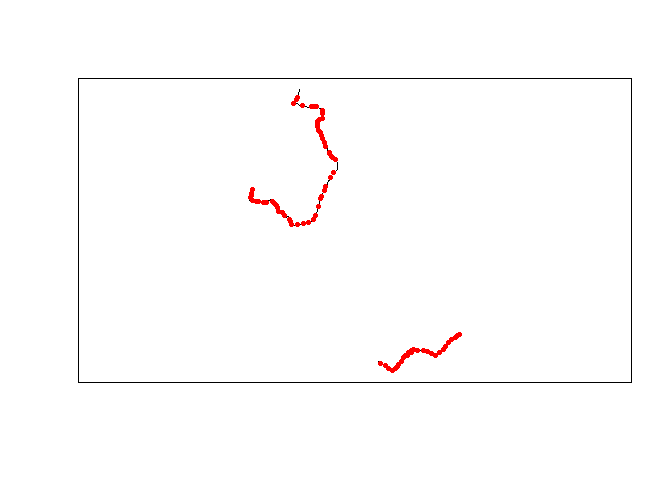

```r
poa_small_shapes_sf <- gtfs2gps::gtfs_shapes_as_sf(poa_small)
poa_small_stops_sf <- gtfs2gps::gtfs_stops_as_sf(poa_small)
plot(sf::st_geometry(poa_small_shapes_sf))
plot(sf::st_geometry(poa_small_stops_sf), pch = 20, col = "red", add = TRUE)
box()
```

After subsetting the data, it is also possible to save it as a new GTFS file using `write_gtfs()`, as shown below.

```r
write_gtfs(poa_small, "poa_small.zip")
```

# Converting to GPS-like format

To convert GTFS to GPS-like format, use `gtfs2gps()`. This is the core function of the package. It takes a GTFS zipped file as an input and returns a `data.table` where each row represents a ‘GPS-like’ data point for every trip in the GTFS file. In summary, this function interpolates the space-time position of each vehicle in each trip considering the network distance and average speed between stops. The function samples the timestamp of each vehicle every 15*m* by default, but the user can set a different value in the `spatial_resolution` argument. See the example below.

```r
  poa_gps <- gtfs2gps("poa_small.zip", spatial_resolution = 50)
  head(poa_gps)
```

```
##    shape_id     trip_id route_type id timestamp shape_pt_lon shape_pt_lat
## 1:   A141-1 A141-1@1#30          3  1      <NA>    -51.14692    -30.14979
## 2:   A141-1 A141-1@1#30          3  2      <NA>    -51.14651    -30.14997
## 3:   A141-1 A141-1@1#30          3  3      <NA>    -51.14610    -30.15014
## 4:   A141-1 A141-1@1#30          3  4  00:30:00    -51.14570    -30.15031
## 5:   A141-1 A141-1@1#30          3  5  00:30:00    -51.14570    -30.15031
## 6:   A141-1 A141-1@1#30          3  6  00:30:15    -51.14532    -30.15048
##    stop_id stop_sequence               speed         dist       cumdist
## 1:    <NA>            NA 1.000000e-12 [km/h]  0.00000 [m]   0.00000 [m]
## 2:    <NA>            NA           NA [km/h] 43.61804 [m]  43.61804 [m]
## 3:    <NA>            NA           NA [km/h] 43.61804 [m]  87.23608 [m]
## 4:     434             1           NA [km/h] 43.32548 [m] 130.56155 [m]
## 5:     434             1 1.000000e-12 [km/h]  0.00000 [m] 130.56155 [m]
## 6:    <NA>            NA 1.013763e+01 [km/h] 41.05718 [m] 171.61874 [m]
##         cumtime trip_number
## 1:  0.00000 [s]           1
## 2:       NA [s]           1
## 3:       NA [s]           1
## 4:       NA [s]           1
## 5:  0.00000 [s]           1
## 6: 14.57992 [s]           1
```

The following figure maps the first 100 data points of the sample data we processed. They can be converted to `simple feature` points or linestring.

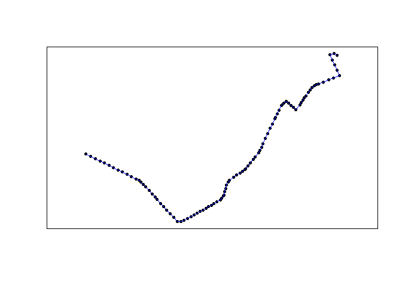

```r
  poa_gps60 <- poa_gps[1:100, ]

  # points
  poa_gps60_sfpoints <- gps_as_sfpoints(poa_gps60)

  # linestring
  poa_gps60_sflinestring <- gps_as_sflinestring(poa_gps60)

  # plot
  plot(sf::st_geometry(poa_gps60_sfpoints), pch = 20)
  plot(sf::st_geometry(poa_gps60_sflinestring), col = "blue", add = TRUE)
  box()
```

The function `gtfs2gps()` automatically recognizes whether the GTFS data brings detailed `stop_times.txt` information or whether it is a `frequency.txt` GTFS file. A sample data of a GTFS with detailed `stop_times.txt` cab be found below:

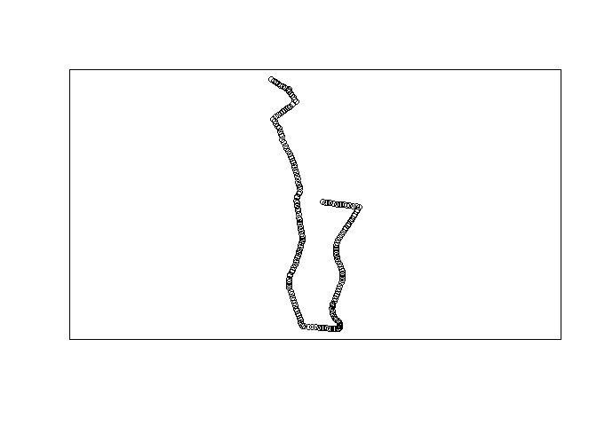

```r
poa <- system.file("extdata/poa.zip", package ="gtfs2gps")

poa_gps <- gtfs2gps(poa, spatial_resolution = 50)

poa_gps_sflinestrig <- gps_as_sfpoints(poa_gps)

plot(sf::st_geometry(poa_gps_sflinestrig[1:200,]))

box()
```

# Methodological note

For a given trip, the function `gtfs2gps` calculates the average speed between each pair of consecutive stops — given by the ratio between cumulative network distance `S` and departure time `t` for a consecutive pair of valid stop_ids (`i`),

[figure not shown]

# Final remarks

If you have any suggestions or want to report an error, please visit the GitHub page of the package [here](https://github.com/ipeaGIT/gtfs2gps).